# Lab #1

Aleah Querns

1/25/2022

# Homework 1

Throughout, my R Markdown file should include:

- text describing what you are doing
- multiple code chunks where you run actual R code
- text describing the output
- an image
- text headers
- at least two examples of non-standard text formatting
- one list

## 1: Create named numerical variable and vector of numbers

**Since you ask for a list somewhere I just decided to include it in this step**

```r
howmanycatsdoIhave<-2

yeehawmagicalvector <- c(1,2,3,4,5,6,7,8,9,10)

listsarefineiguess<-list(howmanycatsdoIhave, yeehawmagicalvector)
```

## 2: Report these produced data objects and then apply at least two functions to each

*Please don’t judge my cat examples I couldn’t think of anything else*

```r
howmanycatsdoIhave
```

```
## [1] 2
```

```r
yeehawmagicalvector
```

```
##  [1]  1  2  3  4  5  6  7  8  9 10
```

```r
#functions for howmanycatsdoIhave
toomanycats<-function (howmanycatsdoIhave) {
  howmanycatsdoIhave^1000
}

toomanycats(howmanycatsdoIhave)
```

```
## [1] 1.071509e+301
```

```r
sadamountofcats<-function (howmanycatsdoIhave) {
  howmanycatsdoIhave/2
}

sadamountofcats(howmanycatsdoIhave)
```

```
## [1] 1
```

```r
#functions for yeehawmagicalvector

mean(yeehawmagicalvector)
```

```
## [1] 5.5
```

```r
max(yeehawmagicalvector)
```

```
## [1] 10
```

(You asked for text describing the output and I’m not sure what this means, but I’ll just roll with it)

I have two cats

I created a vector (yeehawmagicalvector) going from 1-10

1.071509e+301 cats is too many

1 cat is a sad amount of cats

The mean of yeehawmagicalvector is 5.5

The max value of yeehawmagicalvector is 10

## 3: Create a new data frame with three columns and rows. At least one column should contain a character/string variable (e.g. list your top 3 favorite muppets)

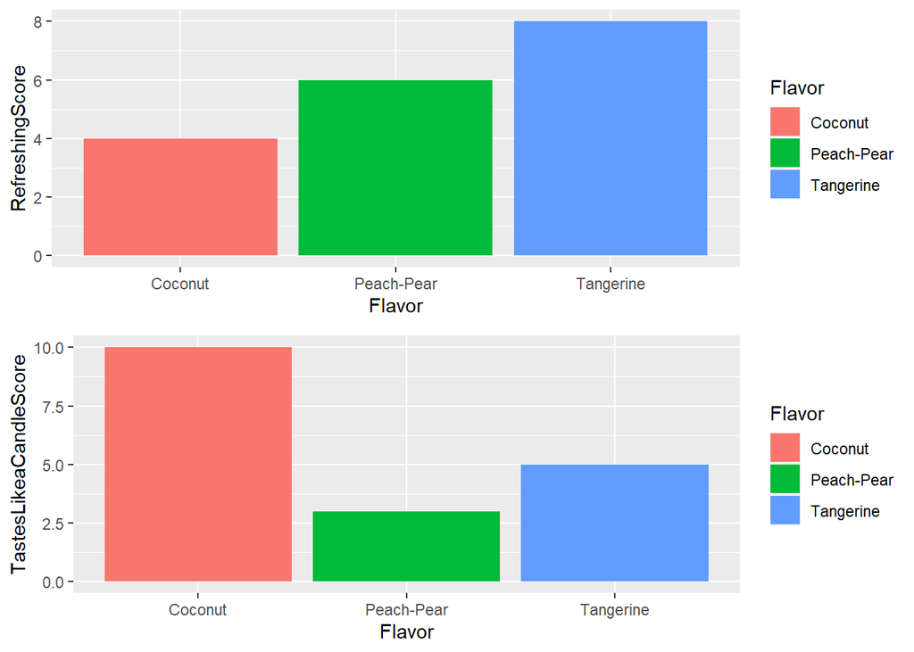

```r
RatingLaCroixFlavors <- data.frame (Flavor  = c("Coconut", "Peach-Pear", "Tangerine"),
                  RefreshingScore  = c(4, 6, 8),
                  TastesLikeaCandleScore = c(10, 3, 5))

library(ggplot2)
library(gridExtra)
p1<-ggplot(RatingLaCroixFlavors, aes(x=Flavor, y=RefreshingScore))+
  geom_bar(stat="identity", aes(fill=Flavor))

p2<-ggplot(RatingLaCroixFlavors, aes(x=Flavor, y=TastesLikeaCandleScore))+
  geom_bar(stat="identity", aes(fill=Flavor))

coolgraph<-grid.arrange(p1,p2)
```

Above, you can see I created an image/graph showing how I rank LaCroix flavors. Coconut is the worst because it’s not very refreshing and tastes like a candle.

## 4: Load a dataset from the R datasets package and report summary information on the dataset and its structure.

```r
data("ChickWeight")
chicken<-ChickWeight

head(chicken)
```

```
##   weight Time Chick Diet
## 1     42    0     1    1
## 2     51    2     1    1
## 3     59    4     1    1
## 4     64    6     1    1
## 5     76    8     1    1
## 6     93   10     1    1
```

```r
tail(chicken)
```

```
##     weight Time Chick Diet
## 573    155   12    50    4
## 574    175   14    50    4
## 575    205   16    50    4
## 576    234   18    50    4
## 577    264   20    50    4
## 578    264   21    50    4
```

```r
nrow(chicken)
```

```
## [1] 578
```

```r
ncol(chicken)
```

```
## [1] 4
```

```r
names(chicken)
```

```
## [1] "weight" "Time"   "Chick"  "Diet"
```

```r
str(chicken)
```

```
## Classes 'nfnGroupedData', 'nfGroupedData', 'groupedData' and 'data.frame':   578 obs. of  4 variables:
##  $ weight: num  42 51 59 64 76 93 106 125 149 171 ...
##  $ Time  : num  0 2 4 6 8 10 12 14 16 18 ...
##  $ Chick : Ord.factor w/ 50 levels "18"<"16"<"15"<..: 15 15 15 15 15 15 15 15 15 15 ...
##  $ Diet  : Factor w/ 4 levels "1","2","3","4": 1 1 1 1 1 1 1 1 1 1 ...
##  - attr(*, "formula")=Class 'formula'  language weight ~ Time | Chick
##   .. ..- attr(*, ".Environment")=<environment: R_EmptyEnv>
##  - attr(*, "outer")=Class 'formula'  language ~Diet
##   .. ..- attr(*, ".Environment")=<environment: R_EmptyEnv>
##  - attr(*, "labels")=List of 2
##   ..$ x: chr "Time"
##   ..$ y: chr "Body weight"
##  - attr(*, "units")=List of 2
##   ..$ x: chr "(days)"
##   ..$ y: chr "(gm)"
```

Above, I summarize the chicken dataset by looking at the head of the data, the tail of the data, number of rows, number of columns, names (of columns), and the structure (classes of varibles).

## 5: Use the ls() function to see that the objects are stored in your workspace. Clear your workspace using the rm(list = ls()) function. Then, run the ls() function to make sure the objects are gone.

```r
ls()
```

```
##  [1] "chicken"              "ChickWeight"          "coolgraph"
##  [4] "howmanycatsdoIhave"   "listsarefineiguess"   "p1"
##  [7] "p2"                   "RatingLaCroixFlavors" "sadamountofcats"
## [10] "toomanycats"          "yeehawmagicalvector"
```

```r
rm(list = ls())

ls()
```

```
## character(0)
```

## 6: Sign up for a free student account on github and include your github username in your Markdown file.

**My GitHub username is akquerns**